# Brain Tumor Detection using Deep Learning (CNN & Transfer Learning)

**Project Overview:**

The goal of this project is to develop a deep learning–based image classification system that detects the presence of brain tumors from MRI images. The project leverages Convolutional Neural Networks (CNNs) and transfer learning to achieve high classification performance.

All codes are written with the help of different LLM platforms with appropriate prompts

**Key objectives:**

Build a reproducible deep learning pipeline

Apply transfer learning for improved accuracy

Evaluate model performance using multiple metrics

Visualize model interpretability using Grad-CAM

**Setup & Imports**

Installs required libraries and imports all dependencies needed for data handling, modeling, visualization, and evaluation.

```python
# Mount Google Drive to access project data
from google.colab import drive
drive.mount('/content/drive')

# Import core libraries
import os
import numpy as np
import pandas as pd

# Import visualization libraries
import matplotlib.pyplot as plt
import seaborn as sns

# Import scikit-learn utilities
from sklearn.model_selection import KFold
from sklearn.metrics import classification_report, confusion_matrix, roc_auc_score, roc_curve

# Import TensorFlow and Keras modules
import tensorflow as tf
from tensorflow import keras
from tensorflow.keras import layers
from tensorflow.keras.preprocessing.image import ImageDataGenerator

# Import pre-trained CNN models
from tensorflow.keras.applications import VGG16, ResNet50, InceptionV3, EfficientNetB0, MobileNetV2

# Import training callbacks
from tensorflow.keras.callbacks import EarlyStopping, ReduceLROnPlateau

# Suppress warning messages
import warnings
warnings.filterwarnings('ignore')

# Set random seeds for reproducibility
np.random.seed(42)
tf.random.set_seed(42)

# Enable XLA optimization for faster execution
tf.config.optimizer.set_jit(True)

# Define dataset directory
DATA_DIR = '/content/drive/MyDrive/DL/Project/'

# Define image input size
IMG_SIZE = (150, 150)

# Define batch size
BATCH_SIZE = 16

# Define number of training epochs
EPOCHS = 30
```

**Image Preprocessing: Center Crop and Resize**

Ensures all MRI images have a consistent aspect ratio by cropping them to a center square before resizing.

```python
# Import image loading and conversion utilities
from tensorflow.keras.preprocessing.image import img_to_array, load_img

#AI Generated
def preprocess_image(img_path, target_size=(150, 150)):
    # Load image in grayscale
    img = load_img(img_path, color_mode='grayscale')

    # Convert image to NumPy array
    img_array = img_to_array(img)

    # Get image height and width
    h, w = img_array.shape[:2]

    # Compute the minimum dimension for square cropping
    min_dim = min(h, w)

    # Calculate starting indices for center crop
    start_h = (h - min_dim) // 2
    start_w = (w - min_dim) // 2

    # Crop image to center square
    img_cropped = img_array[start_h:start_h + min_dim, start_w:start_w + min_dim]

    # Resize image to target size
    img_resized = tf.image.resize(img_cropped, target_size)

    # Normalize pixel values to [0, 1]
    return img_resized / 255.0
```

**Data Augmentation, Class Balance Check, and Generator Setup**

Checks class balance, visualizes sample MRI images, applies data augmentation to improve robustness, and initializes training and validation data generators.

```
Tumor (yes): 155, No Tumor (no): 98 | Imbalance: 61.3%
```

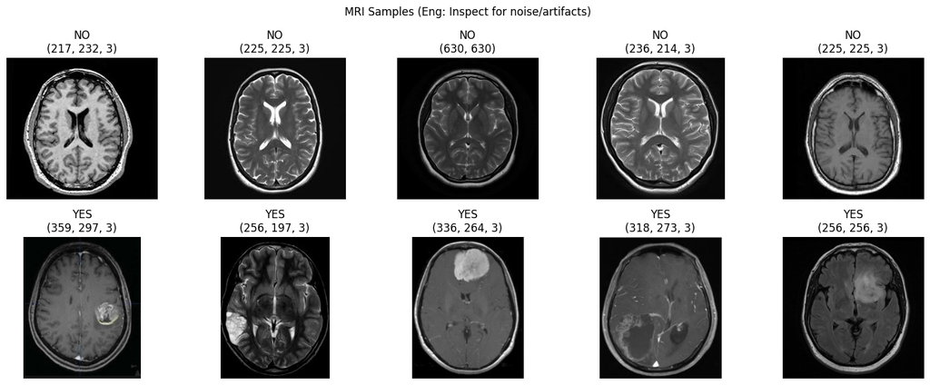

```
Found 203 images belonging to 2 classes.
Found 50 images belonging to 2 classes.
```

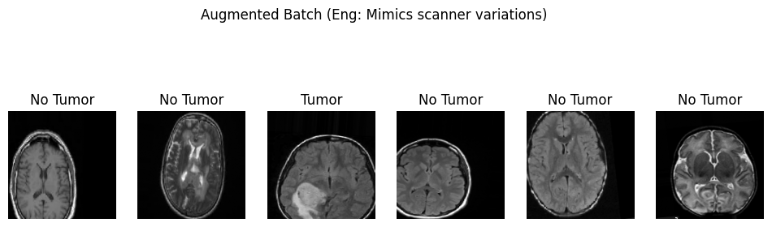

```
✅ Data loaded! (Run Cell 3a next.)
```

```python
# Apply augmentation to simulate domain shifts such as scanner noise  #AI Generated
if 'train_gen' not in locals():

    # Count class samples to check dataset balance
    num_yes = len([f for f in os.listdir(os.path.join(DATA_DIR, 'yes')) if f.lower().endswith(('.png', '.jpg', '.jpeg'))])
    num_no = len([f for f in os.listdir(os.path.join(DATA_DIR, 'no')) if f.lower().endswith(('.png', '.jpg', '.jpeg'))])
    print(f"Tumor (yes): {num_yes}, No Tumor (no): {num_no} | Imbalance: {num_yes / (num_yes + num_no):.1%}")

    # Plot sample images for visual inspection
    def plot_samples(data_dir, classes=['no', 'yes'], rows=2, cols=5):
        fig, axes = plt.subplots(rows, cols, figsize=(15, 6))
        for r, cls in enumerate(classes):
            img_dir = os.path.join(data_dir, cls)
            imgs = [f for f in os.listdir(img_dir) if f.lower().endswith(('.png', '.jpg', '.jpeg'))][:cols]
            for c, img_file in enumerate(imgs):
                img_path = os.path.join(img_dir, img_file)
                img = plt.imread(img_path)
                axes[r, c].imshow(img, cmap='gray' if len(img.shape) == 2 else None)
                axes[r, c].set_title(f"{cls.upper()}\n{img.shape}")
                axes[r, c].axis('off')
        plt.suptitle('MRI Samples')
        plt.tight_layout()
        plt.show()

    # Display sample MRI images
    plot_samples(DATA_DIR)

    # Create data generator with augmentation and validation split
    train_datagen = ImageDataGenerator(
        rescale=1./255,
        validation_split=0.2,
        rotation_range=20,
        width_shift_range=0.2,
        height_shift_range=0.2,
        shear_range=0.2,
        zoom_range=0.2,
        horizontal_flip=True,
        fill_mode='nearest'
    )

    # Create training data generator
    train_gen = train_datagen.flow_from_directory(
        DATA_DIR,
        target_size=IMG_SIZE,
        batch_size=BATCH_SIZE,
        class_mode='binary',
        subset='training',
        shuffle=True,
        seed=42,
        color_mode='grayscale'
    )

    # Create validation data generator
    val_gen = train_datagen.flow_from_directory(
        DATA_DIR,
        target_size=IMG_SIZE,
        batch_size=BATCH_SIZE,
        class_mode='binary',
        subset='validation',
        shuffle=False,
        seed=42,
        color_mode='grayscale'
    )

    # Assign class weights to address class imbalance
    class_weights = {0: 1.0, 1: num_no / num_yes if num_yes > 0 else 1.0}

    # Preview a batch of augmented images
    images, labels = next(train_gen)
    plt.figure(figsize=(12, 4))
    for i in range(min(6, len(images))):
        plt.subplot(1, 6, i + 1)
        plt.imshow(images[i].squeeze(), cmap='gray')
        plt.title('Tumor' if labels[i] == 1 else 'No Tumor')
        plt.axis('off')
    plt.suptitle('Augmented Training Batch')
    plt.show()
```

**Model Architecture: Baseline CNN and Transfer Learning Models**

Defines a lightweight grayscale CNN baseline and multiple transfer learning models using pre-trained backbones for performance comparison.

```python
# Use grayscale inputs to reduce parameters and computational cost #AI Generated
if 'build_baseline_cnn' not in locals():

    def build_baseline_cnn(input_shape=(*IMG_SIZE, 1)):
        # Define a simple CNN architecture
        model = keras.Sequential([
            layers.Conv2D(32, 3, activation='relu', input_shape=input_shape),
            layers.MaxPooling2D(2),
            layers.Conv2D(64, 3, activation='relu'),
            layers.MaxPooling2D(2),
            layers.Conv2D(128, 3, activation='relu'),
            layers.MaxPooling2D(2),
            layers.Flatten(),
            layers.Dropout(0.5),
            layers.Dense(128, activation='relu'),
            layers.Dropout(0.3),
            layers.Dense(1, activation='sigmoid')
        ])

        # Compile the baseline model
        model.compile(
            optimizer='adam',
            loss='binary_crossentropy',
            metrics=['accuracy', tf.keras.metrics.AUC(name='auc')]
        )

        # Print model summary
        print("Baseline Summary (Grayscale):")
        model.summary()
        return model

    def build_transfer_model(backbone_name, input_shape=(*IMG_SIZE, 3), freeze_base=True):
        # Map backbone names to pretrained models
        backbone_map = {
            'VGG16': VGG16(weights='imagenet', include_top=False, input_shape=input_shape),
            'ResNet50': ResNet50(weights='imagenet', include_top=False, input_shape=input_shape),
            'InceptionV3': InceptionV3(weights='imagenet', include_top=False, input_shape=input_shape),
            'EfficientNetB0': EfficientNetB0(weights='imagenet', include_top=False, input_shape=input_shape),
            'MobileNetV2': MobileNetV2(weights='imagenet', include_top=False, input_shape=input_shape)
        }

        # Validate backbone selection
        if backbone_name not in backbone_map:
            raise ValueError(f"Unsupported: {backbone_name}")

        # Select the pretrained backbone
        base = backbone_map[backbone_name]

        # Freeze backbone weights if specified
        if freeze_base:
            base.trainable = False

        # Build transfer learning model
        model = keras.Sequential([
            layers.Conv2D(3, (1, 1), padding='same', activation='relu', input_shape=(*IMG_SIZE, 1)),
            base,
            layers.GlobalAveragePooling2D(),
            layers.BatchNormalization(),
            layers.Dropout(0.5),
            layers.Dense(128, activation='relu'),
            layers.Dropout(0.3),
            layers.Dense(1, activation='sigmoid')
        ])

        # Compile the transfer learning model
        model.compile(
            optimizer=keras.optimizers.Adam(1e-3),
            loss='binary_crossentropy',
            metrics=['accuracy', tf.keras.metrics.AUC(name='auc')]
        )

        # Print model summary
        print(f"{backbone_name} Summary:")
        model.summary()
        return model

    # Define callbacks for early stopping and learning rate scheduling
    callbacks = [
        EarlyStopping(monitor='val_auc', patience=8, restore_best_weights=True, mode='max'),
        ReduceLROnPlateau(monitor='val_loss', factor=0.2, patience=5, min_lr=1e-7)
    ]

    # List of pretrained backbones to evaluate
    backbones = ['VGG16', 'ResNet50', 'InceptionV3', 'EfficientNetB0', 'MobileNetV2']
```

```
✅ Builders ready! (Run 3b for baseline test.)
```

**Baseline CNN Training and Pipeline Verification**

Trains the baseline CNN for a small number of epochs to verify that the data pipeline, model, and evaluation metrics are functioning correctly before running full experiments.

```
--- Training Baseline CNN (Quick Test: 5 Epochs) ---
Baseline Summary (Grayscale):
```

```
Model: "sequential"
```

```
┏━━━━━━━━━━━━━━━━━━━━━━━━━━━━━━━━━┳━━━━━━━━━━━━━━━━━━━━━━━━┳━━━━━━━━━━━━━━━┓
┃ Layer (type)                    ┃ Output Shape           ┃       Param # ┃
┡━━━━━━━━━━━━━━━━━━━━━━━━━━━━━━━━━╇━━━━━━━━━━━━━━━━━━━━━━━━╇━━━━━━━━━━━━━━━┩
│ conv2d (Conv2D)                 │ (None, 148, 148, 32)   │           320 │
├─────────────────────────────────┼────────────────────────┼───────────────┤
│ max_pooling2d (MaxPooling2D)    │ (None, 74, 74, 32)     │             0 │
├─────────────────────────────────┼────────────────────────┼───────────────┤
│ conv2d_1 (Conv2D)               │ (None, 72, 72, 64)     │        18,496 │
├─────────────────────────────────┼────────────────────────┼───────────────┤
│ max_pooling2d_1 (MaxPooling2D)  │ (None, 36, 36, 64)     │             0 │
├─────────────────────────────────┼────────────────────────┼───────────────┤
│ conv2d_2 (Conv2D)               │ (None, 34, 34, 128)    │        73,856 │
├─────────────────────────────────┼────────────────────────┼───────────────┤
│ max_pooling2d_2 (MaxPooling2D)  │ (None, 17, 17, 128)    │             0 │
├─────────────────────────────────┼────────────────────────┼───────────────┤
│ flatten (Flatten)               │ (None, 36992)          │             0 │
├─────────────────────────────────┼────────────────────────┼───────────────┤
│ dropout (Dropout)               │ (None, 36992)          │             0 │
├─────────────────────────────────┼────────────────────────┼───────────────┤
│ dense (Dense)                   │ (None, 128)            │     4,735,104 │
├─────────────────────────────────┼────────────────────────┼───────────────┤
│ dropout_1 (Dropout)             │ (None, 128)            │             0 │
├─────────────────────────────────┼────────────────────────┼───────────────┤
│ dense_1 (Dense)                 │ (None, 1)              │           129 │
└─────────────────────────────────┴────────────────────────┴───────────────┘
```

```
 Total params: 4,827,905 (18.42 MB)
```

```
 Trainable params: 4,827,905 (18.42 MB)
```

```
 Non-trainable params: 0 (0.00 B)
```

```
13/13 ━━━━━━━━━━━━━━━━━━━━ 35s 2s/step - accuracy: 0.4916 - auc: 0.4772 - loss: 0.5574 - val_accuracy: 0.6800 - val_auc: 0.7411 - val_loss: 0.6654 - learning_rate: 0.0010
13/13 ━━━━━━━━━━━━━━━━━━━━ 2s 119ms/step - accuracy: 0.6190 - auc: 0.6683 - loss: 0.5209 - val_accuracy: 0.7600 - val_auc: 0.8285 - val_loss: 0.5292 - learning_rate: 0.0010
13/13 ━━━━━━━━━━━━━━━━━━━━ 2s 118ms/step - accuracy: 0.6592 - auc: 0.7102 - loss: 0.4923 - val_accuracy: 0.7600 - val_auc: 0.8192 - val_loss: 0.5419 - learning_rate: 0.0010
13/13 ━━━━━━━━━━━━━━━━━━━━ 2s 122ms/step - accuracy: 0.5969 - auc: 0.7058 - loss: 0.4928 - val_accuracy: 0.7600 - val_auc: 0.7666 - val_loss: 0.5495 - learning_rate: 0.0010
13/13 ━━━━━━━━━━━━━━━━━━━━ 2s 119ms/step - accuracy: 0.6827 - auc: 0.7282 - loss: 0.4956 - val_accuracy: 0.7600 - val_auc: 0.8633 - val_loss: 0.4935 - learning_rate: 0.0010
```

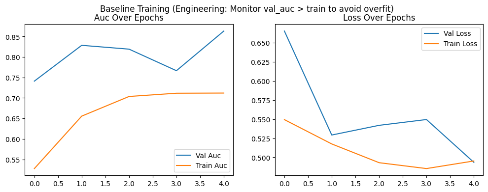

```
4/4 ━━━━━━━━━━━━━━━━━━━━ 1s 141ms/step
Baseline Val AUC: 0.767 (Good start: >0.80 expected)
✅ Baseline works! Next: Full comparison in Step 4.
```

```python
# Train a short baseline model run to validate the pipeline #AI Generated
if 'baseline_model' not in locals():

    # Print training status
    print("--- Training Baseline CNN (Quick Test: 5 Epochs) ---")

    # Build and compile the baseline CNN
    baseline_model = build_baseline_cnn()

    # Train the model for a few epochs
    history_baseline = baseline_model.fit(
        train_gen,
        epochs=5,
        validation_data=val_gen,
        callbacks=callbacks,
        class_weight=class_weights,
        verbose=1
    )

    # Plot training and validation metrics
    def plot_history(hist, title='Baseline Training'):
        fig, axes = plt.subplots(1, 2, figsize=(12, 4))
        for ax, key in [(axes[0], 'auc'), (axes[1], 'loss')]:
            ax.plot(hist.history[f'val_{key}'], label=f'Val {key.title()}')
            ax.plot(hist.history[key], label=f'Train {key.title()}')
            ax.set_title(f'{key.title()} Over Epochs')
            ax.legend()
        plt.suptitle(title)
        plt.show()

    # Visualize training curves
    plot_history(history_baseline)

    # Generate predictions on validation data
    y_pred_base = baseline_model.predict(val_gen).flatten()

    # Compute validation AUC score
    base_auc = roc_auc_score(val_gen.classes, y_pred_base)

    # Print validation AUC result
    print(f"Baseline Val AUC: {base_auc:.3f}")
```

**Ablation Study: Architecture Comparison and Scalability Analysis**

Performs an ablation study to compare baseline and transfer learning architectures using validation AUC, accuracy, and parameter count to assess performance–scalability trade-offs.

```
Reusing baseline (AUC: 0.767402376910017 )

--- Training VGG16 (Frozen Base: ~15 Epochs) ---
Downloading data from https://storage.googleapis.com/tensorflow/keras-applications/vgg16/vgg16_weights_tf_dim_ordering_tf_kernels_notop.h5
58889256/58889256 ━━━━━━━━━━━━━━━━━━━━ 0s 0us/step
Downloading data from https://storage.googleapis.com/tensorflow/keras-applications/resnet/resnet50_weights_tf_dim_ordering_tf_kernels_notop.h5
94765736/94765736 ━━━━━━━━━━━━━━━━━━━━ 1s 0us/step
Downloading data from https://storage.googleapis.com/tensorflow/keras-applications/inception_v3/inception_v3_weights_tf_dim_ordering_tf_kernels_notop.h5
87910968/87910968 ━━━━━━━━━━━━━━━━━━━━ 1s 0us/step
Downloading data from https://storage.googleapis.com/keras-applications/efficientnetb0_notop.h5
16705208/16705208 ━━━━━━━━━━━━━━━━━━━━ 0s 0us/step
Downloading data from https://storage.googleapis.com/tensorflow/keras-applications/mobilenet_v2/mobilenet_v2_weights_tf_dim_ordering_tf_kernels_1.0_224_no_top.h5
9406464/9406464 ━━━━━━━━━━━━━━━━━━━━ 0s 0us/step
VGG16 Summary:
```

```
Model: "sequential_1"
```

```
┏━━━━━━━━━━━━━━━━━━━━━━━━━━━━━━━━━┳━━━━━━━━━━━━━━━━━━━━━━━━┳━━━━━━━━━━━━━━━┓
┃ Layer (type)                    ┃ Output Shape           ┃       Param # ┃
┡━━━━━━━━━━━━━━━━━━━━━━━━━━━━━━━━━╇━━━━━━━━━━━━━━━━━━━━━━━━╇━━━━━━━━━━━━━━━┩
│ conv2d_97 (Conv2D)              │ (None, 150, 150, 3)    │             6 │
├─────────────────────────────────┼────────────────────────┼───────────────┤
│ vgg16 (Functional)              │ (None, 4, 4, 512)      │    14,714,688 │
├─────────────────────────────────┼────────────────────────┼───────────────┤
│ global_average_pooling2d        │ (None, 512)            │             0 │
│ (GlobalAveragePooling2D)        │                        │               │
├─────────────────────────────────┼────────────────────────┼───────────────┤
│ batch_normalization_94          │ (None, 512)            │         2,048 │
│ (BatchNormalization)            │                        │               │
├─────────────────────────────────┼────────────────────────┼───────────────┤
│ dropout_2 (Dropout)             │ (None, 512)            │             0 │
├─────────────────────────────────┼────────────────────────┼───────────────┤
│ dense_2 (Dense)                 │ (None, 128)            │        65,664 │
├─────────────────────────────────┼────────────────────────┼───────────────┤
│ dropout_3 (Dropout)             │ (None, 128)            │             0 │
├─────────────────────────────────┼────────────────────────┼───────────────┤
│ dense_3 (Dense)                 │ (None, 1)              │           129 │
└─────────────────────────────────┴────────────────────────┴───────────────┘
```

```
 Total params: 14,782,535 (56.39 MB)
```

```
 Trainable params: 66,823 (261.03 KB)
```

```
 Non-trainable params: 14,715,712 (56.14 MB)
```

```
13/13 ━━━━━━━━━━━━━━━━━━━━ 38s 2s/step - accuracy: 0.5117 - auc: 0.5656 - loss: 0.7554 - val_accuracy: 0.4400 - val_auc: 0.6290 - val_loss: 0.7532 - learning_rate: 0.0010
13/13 ━━━━━━━━━━━━━━━━━━━━ 2s 141ms/step - accuracy: 0.5898 - auc: 0.6855 - loss: 0.5446 - val_accuracy: 0.6800 - val_auc: 0.7097 - val_loss: 0.6406 - learning_rate: 0.0010
13/13 ━━━━━━━━━━━━━━━━━━━━ 2s 142ms/step - accuracy: 0.6926 - auc: 0.8124 - loss: 0.4265 - val_accuracy: 0.7200 - val_auc: 0.8277 - val_loss: 0.5722 - learning_rate: 0.0010
13/13 ━━━━━━━━━━━━━━━━━━━━ 2s 138ms/step - accuracy: 0.7285 - auc: 0.8106 - loss: 0.4376 - val_accuracy: 0.6400 - val_auc: 0.7564 - val_loss: 0.6008 - learning_rate: 0.0010
13/13 ━━━━━━━━━━━━━━━━━━━━ 2s 163ms/step - accuracy: 0.7537 - auc: 0.8503 - loss: 0.3782 - val_accuracy: 0.6200 - val_auc: 0.7020 - val_loss: 0.6338 - learning_rate: 0.0010
13/13 ━━━━━━━━━━━━━━━━━━━━ 3s 189ms/step - accuracy: 0.7227 - auc: 0.8146 - loss: 0.4551 - val_accuracy: 0.6400 - val_auc: 0.8599 - val_loss: 0.5953 - learning_rate: 0.0010
13/13 ━━━━━━━━━━━━━━━━━━━━ 2s 141ms/step - accuracy: 0.7555 - auc: 0.8499 - loss: 0.3767 - val_accuracy: 0.6400 - val_auc: 0.8251 - val_loss: 0.5937 - learning_rate: 0.0010
13/13 ━━━━━━━━━━━━━━━━━━━━ 2s 140ms/step - accuracy: 0.7142 - auc: 0.8246 - loss: 0.3954 - val_accuracy: 0.6200 - val_auc: 0.8489 - val_loss: 0.5676 - learning_rate: 0.0010
13/13 ━━━━━━━━━━━━━━━━━━━━ 2s 141ms/step - accuracy: 0.7083 - auc: 0.7728 - loss: 0.4959 - val_accuracy: 0.6400 - val_auc: 0.8523 - val_loss: 0.5582 - learning_rate: 0.0010
13/13 ━━━━━━━━━━━━━━━━━━━━ 2s 142ms/step - accuracy: 0.7399 - auc: 0.8296 - loss: 0.4094 - val_accuracy: 0.6800 - val_auc: 0.8260 - val_loss: 0.5792 - learning_rate: 0.0010
13/13 ━━━━━━━━━━━━━━━━━━━━ 2s 145ms/step - accuracy: 0.7723 - auc: 0.8605 - loss: 0.3690 - val_accuracy: 0.6600 - val_auc: 0.8421 - val_loss: 0.5837 - learning_rate: 0.0010
13/13 ━━━━━━━━━━━━━━━━━━━━ 2s 187ms/step - accuracy: 0.7706 - auc: 0.8705 - loss: 0.3599 - val_accuracy: 0.6800 - val_auc: 0.8175 - val_loss: 0.5769 - learning_rate: 0.0010
13/13 ━━━━━━━━━━━━━━━━━━━━ 2s 170ms/step - accuracy: 0.7239 - auc: 0.8238 - loss: 0.4173 - val_accuracy: 0.6600 - val_auc: 0.8175 - val_loss: 0.5657 - learning_rate: 0.0010
13/13 ━━━━━━━━━━━━━━━━━━━━ 2s 150ms/step - accuracy: 0.8271 - auc: 0.9343 - loss: 0.2747 - val_accuracy: 0.7000 - val_auc: 0.8947 - val_loss: 0.5317 - learning_rate: 0.0010
13/13 ━━━━━━━━━━━━━━━━━━━━ 2s 144ms/step - accuracy: 0.7931 - auc: 0.8726 - loss: 0.3475 - val_accuracy: 0.6600 - val_auc: 0.8413 - val_loss: 0.5634 - learning_rate: 0.0010

--- Training ResNet50 (Frozen Base: ~15 Epochs) ---
ResNet50 Summary:
```

```
Model: "sequential_2"
```

```
┏━━━━━━━━━━━━━━━━━━━━━━━━━━━━━━━━━┳━━━━━━━━━━━━━━━━━━━━━━━━┳━━━━━━━━━━━━━━━┓
┃ Layer (type)                    ┃ Output Shape           ┃       Param # ┃
┡━━━━━━━━━━━━━━━━━━━━━━━━━━━━━━━━━╇━━━━━━━━━━━━━━━━━━━━━━━━╇━━━━━━━━━━━━━━━┩
│ conv2d_192 (Conv2D)             │ (None, 150, 150, 3)    │             6 │
├─────────────────────────────────┼────────────────────────┼───────────────┤
│ resnet50 (Functional)           │ (None, 5, 5, 2048)     │    23,587,712 │
├─────────────────────────────────┼────────────────────────┼───────────────┤
│ global_average_pooling2d_1      │ (None, 2048)           │             0 │
│ (GlobalAveragePooling2D)        │                        │               │
├─────────────────────────────────┼────────────────────────┼───────────────┤
│ batch_normalization_189         │ (None, 2048)           │         8,192 │
│ (BatchNormalization)            │                        │               │
├─────────────────────────────────┼────────────────────────┼───────────────┤
│ dropout_4 (Dropout)             │ (None, 2048)           │             0 │
├─────────────────────────────────┼────────────────────────┼───────────────┤
│ dense_4 (Dense)                 │ (None, 128)            │       262,272 │
├─────────────────────────────────┼────────────────────────┼───────────────┤
│ dropout_5 (Dropout)             │ (None, 128)            │             0 │
├─────────────────────────────────┼────────────────────────┼───────────────┤
│ dense_5 (Dense)                 │ (None, 1)              │           129 │
└─────────────────────────────────┴────────────────────────┴───────────────┘
```

```
 Total params: 23,858,311 (91.01 MB)
```

```
 Trainable params: 266,503 (1.02 MB)
```

```
 Non-trainable params: 23,591,808 (90.00 MB)
```

```
13/13 ━━━━━━━━━━━━━━━━━━━━ 35s 2s/step - accuracy: 0.3845 - auc: 0.4190 - loss: 0.5596 - val_accuracy: 0.3800 - val_auc: 0.5484 - val_loss: 0.7532 - learning_rate: 0.0010
13/13 ━━━━━━━━━━━━━━━━━━━━ 2s 149ms/step - accuracy: 0.5936 - auc: 0.6522 - loss: 0.5262 - val_accuracy: 0.3800 - val_auc: 0.7691 - val_loss: 0.8171 - learning_rate: 0.0010
13/13 ━━━━━━━━━━━━━━━━━━━━ 2s 174ms/step - accuracy: 0.6378 - auc: 0.7061 - loss: 0.4952 - val_accuracy: 0.3800 - val_auc: 0.6664 - val_loss: 0.8194 - learning_rate: 0.0010
13/13 ━━━━━━━━━━━━━━━━━━━━ 2s 172ms/step - accuracy: 0.6515 - auc: 0.7051 - loss: 0.4938 - val_accuracy: 0.3800 - val_auc: 0.7963 - val_loss: 0.7636 - learning_rate: 0.0010
13/13 ━━━━━━━━━━━━━━━━━━━━ 2s 130ms/step - accuracy: 0.5579 - auc: 0.6462 - loss: 0.5222 - val_accuracy: 0.3800 - val_auc: 0.7487 - val_loss: 0.7341 - learning_rate: 0.0010
13/13 ━━━━━━━━━━━━━━━━━━━━ 2s 131ms/step - accuracy: 0.6551 - auc: 0.6889 - loss: 0.5212 - val_accuracy: 0.3800 - val_auc: 0.7767 - val_loss: 0.7112 - learning_rate: 0.0010
13/13 ━━━━━━━━━━━━━━━━━━━━ 2s 135ms/step - accuracy: 0.6629 - auc: 0.7072 - loss: 0.5144 - val_accuracy: 0.3800 - val_auc: 0.7334 - val_loss: 0.7241 - learning_rate: 0.0010
13/13 ━━━━━━━━━━━━━━━━━━━━ 2s 135ms/step - accuracy: 0.6754 - auc: 0.7135 - loss: 0.4954 - val_accuracy: 0.3800 - val_auc: 0.7122 - val_loss: 0.7232 - learning_rate: 0.0010
13/13 ━━━━━━━━━━━━━━━━━━━━ 2s 136ms/step - accuracy: 0.6379 - auc: 0.6844 - loss: 0.4905 - val_accuracy: 0.3800 - val_auc: 0.7504 - val_loss: 0.7093 - learning_rate: 0.0010
13/13 ━━━━━━━━━━━━━━━━━━━━ 2s 184ms/step - accuracy: 0.6506 - auc: 0.7030 - loss: 0.4999 - val_accuracy: 0.3800 - val_auc: 0.7657 - val_loss: 0.7751 - learning_rate: 0.0010
13/13 ━━━━━━━━━━━━━━━━━━━━ 2s 160ms/step - accuracy: 0.6852 - auc: 0.6810 - loss: 0.5072 - val_accuracy: 0.3800 - val_auc: 0.8846 - val_loss: 0.7047 - learning_rate: 0.0010
13/13 ━━━━━━━━━━━━━━━━━━━━ 2s 138ms/step - accuracy: 0.6704 - auc: 0.7207 - loss: 0.4822 - val_accuracy: 0.3800 - val_auc: 0.8209 - val_loss: 0.7018 - learning_rate: 0.0010
13/13 ━━━━━━━━━━━━━━━━━━━━ 2s 133ms/step - accuracy: 0.6654 - auc: 0.7356 - loss: 0.4677 - val_accuracy: 0.3800 - val_auc: 0.7216 - val_loss: 0.7041 - learning_rate: 0.0010
13/13 ━━━━━━━━━━━━━━━━━━━━ 2s 136ms/step - accuracy: 0.6656 - auc: 0.7612 - loss: 0.4664 - val_accuracy: 0.4000 - val_auc: 0.7988 - val_loss: 0.6929 - learning_rate: 0.0010
13/13 ━━━━━━━━━━━━━━━━━━━━ 2s 137ms/step - accuracy: 0.6678 - auc: 0.7271 - loss: 0.4726 - val_accuracy: 0.5400 - val_auc: 0.7479 - val_loss: 0.6891 - learning_rate: 0.0010
```

[output not shown]

```
--- Training InceptionV3 (Frozen Base: ~15 Epochs) ---
InceptionV3 Summary:
```

```
Model: "sequential_3"
```

```
┏━━━━━━━━━━━━━━━━━━━━━━━━━━━━━━━━━┳━━━━━━━━━━━━━━━━━━━━━━━━┳━━━━━━━━━━━━━━━┓
┃ Layer (type)                    ┃ Output Shape           ┃       Param # ┃
┡━━━━━━━━━━━━━━━━━━━━━━━━━━━━━━━━━╇━━━━━━━━━━━━━━━━━━━━━━━━╇━━━━━━━━━━━━━━━┩
│ conv2d_287 (Conv2D)             │ (None, 150, 150, 3)    │             6 │
├─────────────────────────────────┼────────────────────────┼───────────────┤
│ inception_v3 (Functional)       │ (None, 3, 3, 2048)     │    21,802,784 │
├─────────────────────────────────┼────────────────────────┼───────────────┤
│ global_average_pooling2d_2      │ (None, 2048)           │             0 │
│ (GlobalAveragePooling2D)        │                        │               │
├─────────────────────────────────┼────────────────────────┼───────────────┤
│ batch_normalization_284         │ (None, 2048)           │         8,192 │
│ (BatchNormalization)            │                        │               │
├─────────────────────────────────┼────────────────────────┼───────────────┤
│ dropout_6 (Dropout)             │ (None, 2048)           │             0 │
├─────────────────────────────────┼────────────────────────┼───────────────┤
│ dense_6 (Dense)                 │ (None, 128)            │       262,272 │
├─────────────────────────────────┼────────────────────────┼───────────────┤
│ dropout_7 (Dropout)             │ (None, 128)            │             0 │
├─────────────────────────────────┼────────────────────────┼───────────────┤
│ dense_7 (Dense)                 │ (None, 1)              │           129 │
└─────────────────────────────────┴────────────────────────┴───────────────┘
```

```
 Total params: 22,073,383 (84.20 MB)
```

```
 Trainable params: 266,503 (1.02 MB)
```

```
 Non-trainable params: 21,806,880 (83.19 MB)
```

```
13/13 ━━━━━━━━━━━━━━━━━━━━ 50s 2s/step - accuracy: 0.5448 - auc: 0.6534 - loss: 0.8266 - val_accuracy: 0.6400 - val_auc: 0.8523 - val_loss: 0.9715 - learning_rate: 0.0010
13/13 ━━━━━━━━━━━━━━━━━━━━ 2s 150ms/step - accuracy: 0.6091 - auc: 0.7721 - loss: 0.6406 - val_accuracy: 0.7200 - val_auc: 0.8905 - val_loss: 0.7018 - learning_rate: 0.0010
13/13 ━━━━━━━━━━━━━━━━━━━━ 3s 190ms/step - accuracy: 0.7632 - auc: 0.8613 - loss: 0.4235 - val_accuracy: 0.6600 - val_auc: 0.8998 - val_loss: 0.8915 - learning_rate: 0.0010
13/13 ━━━━━━━━━━━━━━━━━━━━ 2s 157ms/step - accuracy: 0.8535 - auc: 0.9124 - loss: 0.3115 - val_accuracy: 0.7800 - val_auc: 0.8956 - val_loss: 0.5931 - learning_rate: 0.0010
13/13 ━━━━━━━━━━━━━━━━━━━━ 2s 147ms/step - accuracy: 0.8314 - auc: 0.9086 - loss: 0.3706 - val_accuracy: 0.7400 - val_auc: 0.9211 - val_loss: 0.5598 - learning_rate: 0.0010
13/13 ━━━━━━━━━━━━━━━━━━━━ 2s 146ms/step - accuracy: 0.8232 - auc: 0.9056 - loss: 0.3481 - val_accuracy: 0.8800 - val_auc: 0.9457 - val_loss: 0.3507 - learning_rate: 0.0010
13/13 ━━━━━━━━━━━━━━━━━━━━ 2s 131ms/step - accuracy: 0.8422 - auc: 0.9266 - loss: 0.3205 - val_accuracy: 0.9000 - val_auc: 0.9372 - val_loss: 0.3540 - learning_rate: 0.0010
13/13 ━━━━━━━━━━━━━━━━━━━━ 2s 138ms/step - accuracy: 0.8737 - auc: 0.9332 - loss: 0.3282 - val_accuracy: 0.8200 - val_auc: 0.9015 - val_loss: 0.4213 - learning_rate: 0.0010
13/13 ━━━━━━━━━━━━━━━━━━━━ 2s 173ms/step - accuracy: 0.8657 - auc: 0.9218 - loss: 0.3270 - val_accuracy: 0.8400 - val_auc: 0.9007 - val_loss: 0.4178 - learning_rate: 0.0010
13/13 ━━━━━━━━━━━━━━━━━━━━ 2s 185ms/step - accuracy: 0.8172 - auc: 0.9072 - loss: 0.3603 - val_accuracy: 0.8600 - val_auc: 0.9363 - val_loss: 0.4034 - learning_rate: 0.0010
13/13 ━━━━━━━━━━━━━━━━━━━━ 2s 136ms/step - accuracy: 0.8777 - auc: 0.9368 - loss: 0.3342 - val_accuracy: 0.7800 - val_auc: 0.8803 - val_loss: 0.4682 - learning_rate: 0.0010
13/13 ━━━━━━━━━━━━━━━━━━━━ 2s 140ms/step - accuracy: 0.8156 - auc: 0.9282 - loss: 0.3169 - val_accuracy: 0.8000 - val_auc: 0.8769 - val_loss: 0.4664 - learning_rate: 2.0000e-04
13/13 ━━━━━━━━━━━━━━━━━━━━ 2s 140ms/step - accuracy: 0.8276 - auc: 0.9161 - loss: 0.3595 - val_accuracy: 0.9000 - val_auc: 0.9380 - val_loss: 0.3202 - learning_rate: 2.0000e-04
13/13 ━━━━━━━━━━━━━━━━━━━━ 2s 150ms/step - accuracy: 0.8763 - auc: 0.9533 - loss: 0.2261 - val_accuracy: 0.8200 - val_auc: 0.9542 - val_loss: 0.2419 - learning_rate: 2.0000e-04
13/13 ━━━━━━━━━━━━━━━━━━━━ 2s 141ms/step - accuracy: 0.8609 - auc: 0.9296 - loss: 0.2968 - val_accuracy: 0.8400 - val_auc: 0.8769 - val_loss: 0.5968 - learning_rate: 2.0000e-04

--- Training EfficientNetB0 (Frozen Base: ~15 Epochs) ---
EfficientNetB0 Summary:
```

```
Model: "sequential_4"
```

```
┏━━━━━━━━━━━━━━━━━━━━━━━━━━━━━━━━━┳━━━━━━━━━━━━━━━━━━━━━━━━┳━━━━━━━━━━━━━━━┓
┃ Layer (type)                    ┃ Output Shape           ┃       Param # ┃
┡━━━━━━━━━━━━━━━━━━━━━━━━━━━━━━━━━╇━━━━━━━━━━━━━━━━━━━━━━━━╇━━━━━━━━━━━━━━━┩
│ conv2d_382 (Conv2D)             │ (None, 150, 150, 3)    │             6 │
├─────────────────────────────────┼────────────────────────┼───────────────┤
│ efficientnetb0 (Functional)     │ (None, 5, 5, 1280)     │     4,049,571 │
├─────────────────────────────────┼────────────────────────┼───────────────┤
│ global_average_pooling2d_3      │ (None, 1280)           │             0 │
│ (GlobalAveragePooling2D)        │                        │               │
├─────────────────────────────────┼────────────────────────┼───────────────┤
│ batch_normalization_379         │ (None, 1280)           │         5,120 │
│ (BatchNormalization)            │                        │               │
├─────────────────────────────────┼────────────────────────┼───────────────┤
│ dropout_8 (Dropout)             │ (None, 1280)           │             0 │
├─────────────────────────────────┼────────────────────────┼───────────────┤
│ dense_8 (Dense)                 │ (None, 128)            │       163,968 │
├─────────────────────────────────┼────────────────────────┼───────────────┤
│ dropout_9 (Dropout)             │ (None, 128)            │             0 │
├─────────────────────────────────┼────────────────────────┼───────────────┤
│ dense_9 (Dense)                 │ (None, 1)              │           129 │
└─────────────────────────────────┴────────────────────────┴───────────────┘
```

```
 Total params: 4,218,794 (16.09 MB)
```

```
 Trainable params: 166,663 (651.03 KB)
```

```
 Non-trainable params: 4,052,131 (15.46 MB)
```

```
13/13 ━━━━━━━━━━━━━━━━━━━━ 78s 4s/step - accuracy: 0.4826 - auc: 0.4205 - loss: 0.7840 - val_accuracy: 0.3800 - val_auc: 0.5000 - val_loss: 0.9075 - learning_rate: 0.0010
13/13 ━━━━━━━━━━━━━━━━━━━━ 2s 125ms/step - accuracy: 0.5725 - auc: 0.5448 - loss: 0.6816 - val_accuracy: 0.3800 - val_auc: 0.5000 - val_loss: 0.7637 - learning_rate: 0.0010
13/13 ━━━━━━━━━━━━━━━━━━━━ 2s 127ms/step - accuracy: 0.4873 - auc: 0.4962 - loss: 0.7152 - val_accuracy: 0.3800 - val_auc: 0.5000 - val_loss: 0.7681 - learning_rate: 0.0010
13/13 ━━━━━━━━━━━━━━━━━━━━ 2s 123ms/step - accuracy: 0.4961 - auc: 0.5164 - loss: 0.7346 - val_accuracy: 0.3800 - val_auc: 0.5000 - val_loss: 0.7502 - learning_rate: 0.0010
13/13 ━━━━━━━━━━━━━━━━━━━━ 2s 122ms/step - accuracy: 0.4993 - auc: 0.5387 - loss: 0.6826 - val_accuracy: 0.3800 - val_auc: 0.5000 - val_loss: 0.7063 - learning_rate: 0.0010
13/13 ━━━━━━━━━━━━━━━━━━━━ 2s 148ms/step - accuracy: 0.5556 - auc: 0.5537 - loss: 0.7679 - val_accuracy: 0.3800 - val_auc: 0.6248 - val_loss: 0.7390 - learning_rate: 0.0010
13/13 ━━━━━━━━━━━━━━━━━━━━ 3s 154ms/step - accuracy: 0.4141 - auc: 0.3786 - loss: 0.9375 - val_accuracy: 0.3800 - val_auc: 0.5705 - val_loss: 0.7314 - learning_rate: 0.0010
13/13 ━━━━━━━━━━━━━━━━━━━━ 2s 122ms/step - accuracy: 0.5519 - auc: 0.5181 - loss: 0.6641 - val_accuracy: 0.3800 - val_auc: 0.4839 - val_loss: 0.7076 - learning_rate: 0.0010
13/13 ━━━━━━━━━━━━━━━━━━━━ 2s 128ms/step - accuracy: 0.5339 - auc: 0.5412 - loss: 0.7081 - val_accuracy: 0.3800 - val_auc: 0.5000 - val_loss: 0.7226 - learning_rate: 0.0010
13/13 ━━━━━━━━━━━━━━━━━━━━ 2s 125ms/step - accuracy: 0.4981 - auc: 0.4622 - loss: 0.7488 - val_accuracy: 0.3800 - val_auc: 0.5000 - val_loss: 0.7033 - learning_rate: 0.0010
13/13 ━━━━━━━━━━━━━━━━━━━━ 2s 131ms/step - accuracy: 0.5045 - auc: 0.4396 - loss: 0.7509 - val_accuracy: 0.3800 - val_auc: 0.7394 - val_loss: 0.7133 - learning_rate: 0.0010
13/13 ━━━━━━━━━━━━━━━━━━━━ 2s 126ms/step - accuracy: 0.5502 - auc: 0.5487 - loss: 0.6200 - val_accuracy: 0.3800 - val_auc: 0.5000 - val_loss: 0.7422 - learning_rate: 0.0010
13/13 ━━━━━━━━━━━━━━━━━━━━ 2s 163ms/step - accuracy: 0.4432 - auc: 0.4376 - loss: 0.7946 - val_accuracy: 0.6200 - val_auc: 0.5102 - val_loss: 0.6871 - learning_rate: 0.0010
13/13 ━━━━━━━━━━━━━━━━━━━━ 2s 171ms/step - accuracy: 0.5503 - auc: 0.5582 - loss: 0.6153 - val_accuracy: 0.3800 - val_auc: 0.5000 - val_loss: 0.7119 - learning_rate: 0.0010
13/13 ━━━━━━━━━━━━━━━━━━━━ 2s 125ms/step - accuracy: 0.4922 - auc: 0.4654 - loss: 0.6687 - val_accuracy: 0.3800 - val_auc: 0.5000 - val_loss: 0.7044 - learning_rate: 0.0010

--- Training MobileNetV2 (Frozen Base: ~15 Epochs) ---
MobileNetV2 Summary:
```

```
Model: "sequential_5"
```

```
┏━━━━━━━━━━━━━━━━━━━━━━━━━━━━━━━━━┳━━━━━━━━━━━━━━━━━━━━━━━━┳━━━━━━━━━━━━━━━┓
┃ Layer (type)                    ┃ Output Shape           ┃       Param # ┃
┡━━━━━━━━━━━━━━━━━━━━━━━━━━━━━━━━━╇━━━━━━━━━━━━━━━━━━━━━━━━╇━━━━━━━━━━━━━━━┩
│ conv2d_477 (Conv2D)             │ (None, 150, 150, 3)    │             6 │
├─────────────────────────────────┼────────────────────────┼───────────────┤
│ mobilenetv2_1.00_224            │ (None, 5, 5, 1280)     │     2,257,984 │
│ (Functional)                    │                        │               │
├─────────────────────────────────┼────────────────────────┼───────────────┤
│ global_average_pooling2d_4      │ (None, 1280)           │             0 │
│ (GlobalAveragePooling2D)        │                        │               │
├─────────────────────────────────┼────────────────────────┼───────────────┤
│ batch_normalization_474         │ (None, 1280)           │         5,120 │
│ (BatchNormalization)            │                        │               │
├─────────────────────────────────┼────────────────────────┼───────────────┤
│ dropout_10 (Dropout)            │ (None, 1280)           │             0 │
├─────────────────────────────────┼────────────────────────┼───────────────┤
│ dense_10 (Dense)                │ (None, 128)            │       163,968 │
├─────────────────────────────────┼────────────────────────┼───────────────┤
│ dropout_11 (Dropout)            │ (None, 128)            │             0 │
├─────────────────────────────────┼────────────────────────┼───────────────┤
│ dense_11 (Dense)                │ (None, 1)              │           129 │
└─────────────────────────────────┴────────────────────────┴───────────────┘
```

```
 Total params: 2,427,207 (9.26 MB)
```

```
 Trainable params: 166,663 (651.03 KB)
```

```
 Non-trainable params: 2,260,544 (8.62 MB)
```

```
13/13 ━━━━━━━━━━━━━━━━━━━━ 50s 2s/step - accuracy: 0.5400 - auc: 0.5686 - loss: 0.8129 - val_accuracy: 0.6600 - val_auc: 0.9389 - val_loss: 0.6380 - learning_rate: 0.0010
13/13 ━━━━━━━━━━━━━━━━━━━━ 2s 131ms/step - accuracy: 0.7070 - auc: 0.8268 - loss: 0.5526 - val_accuracy: 0.8600 - val_auc: 0.9440 - val_loss: 0.3504 - learning_rate: 0.0010
13/13 ━━━━━━━━━━━━━━━━━━━━ 2s 132ms/step - accuracy: 0.8188 - auc: 0.8588 - loss: 0.3976 - val_accuracy: 0.8600 - val_auc: 0.9474 - val_loss: 0.3598 - learning_rate: 0.0010
13/13 ━━━━━━━━━━━━━━━━━━━━ 2s 144ms/step - accuracy: 0.8193 - auc: 0.8967 - loss: 0.3219 - val_accuracy: 0.8600 - val_auc: 0.9406 - val_loss: 0.3234 - learning_rate: 0.0010
13/13 ━━━━━━━━━━━━━━━━━━━━ 2s 179ms/step - accuracy: 0.8119 - auc: 0.8829 - loss: 0.3624 - val_accuracy: 0.9000 - val_auc: 0.9626 - val_loss: 0.2770 - learning_rate: 0.0010
13/13 ━━━━━━━━━━━━━━━━━━━━ 2s 133ms/step - accuracy: 0.7426 - auc: 0.8449 - loss: 0.5065 - val_accuracy: 0.9400 - val_auc: 0.9864 - val_loss: 0.2392 - learning_rate: 0.0010
13/13 ━━━━━━━━━━━━━━━━━━━━ 2s 120ms/step - accuracy: 0.8859 - auc: 0.9552 - loss: 0.2104 - val_accuracy: 0.8800 - val_auc: 0.9703 - val_loss: 0.2460 - learning_rate: 0.0010
13/13 ━━━━━━━━━━━━━━━━━━━━ 2s 124ms/step - accuracy: 0.8378 - auc: 0.9157 - loss: 0.3100 - val_accuracy: 0.8800 - val_auc: 0.9745 - val_loss: 0.2575 - learning_rate: 0.0010
13/13 ━━━━━━━━━━━━━━━━━━━━ 2s 121ms/step - accuracy: 0.8393 - auc: 0.8916 - loss: 0.3601 - val_accuracy: 0.8800 - val_auc: 0.9567 - val_loss: 0.2903 - learning_rate: 0.0010
13/13 ━━━━━━━━━━━━━━━━━━━━ 2s 131ms/step - accuracy: 0.8757 - auc: 0.9270 - loss: 0.2874 - val_accuracy: 0.9600 - val_auc: 0.9881 - val_loss: 0.2513 - learning_rate: 0.0010
13/13 ━━━━━━━━━━━━━━━━━━━━ 2s 123ms/step - accuracy: 0.8058 - auc: 0.9250 - loss: 0.2602 - val_accuracy: 0.9200 - val_auc: 0.9830 - val_loss: 0.2256 - learning_rate: 0.0010
13/13 ━━━━━━━━━━━━━━━━━━━━ 2s 175ms/step - accuracy: 0.8534 - auc: 0.9268 - loss: 0.2870 - val_accuracy: 0.8600 - val_auc: 0.9728 - val_loss: 0.2481 - learning_rate: 0.0010
13/13 ━━━━━━━━━━━━━━━━━━━━ 2s 147ms/step - accuracy: 0.8264 - auc: 0.9046 - loss: 0.3247 - val_accuracy: 0.9600 - val_auc: 0.9779 - val_loss: 0.2216 - learning_rate: 0.0010
13/13 ━━━━━━━━━━━━━━━━━━━━ 2s 127ms/step - accuracy: 0.7841 - auc: 0.9076 - loss: 0.3278 - val_accuracy: 0.9800 - val_auc: 1.0000 - val_loss: 0.1622 - learning_rate: 0.0010
13/13 ━━━━━━━━━━━━━━━━━━━━ 2s 121ms/step - accuracy: 0.8106 - auc: 0.8839 - loss: 0.3792 - val_accuracy: 0.9800 - val_auc: 0.9813 - val_loss: 0.1895 - learning_rate: 0.0010

🏆 Ablation Results (Sorted by Val AUC):
            Model  Val AUC  Val Acc  Params (M)
5     MobileNetV2    0.995     0.90       2.427
3     InceptionV3    0.915     0.82      22.073
1           VGG16    0.862     0.70      14.783
0        Baseline    0.767     0.78       4.828
2        ResNet50    0.761     0.40      23.858
4  EfficientNetB0    0.759     0.38       4.219
```

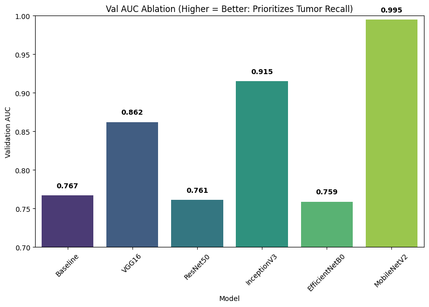

```
🚀 Best Backbone: MobileNetV2 (AUC: 0.995, Params: 2.4M)
   Why? High AUC + low params = Eng winner (e.g., fast inference on clinic hardware).
```

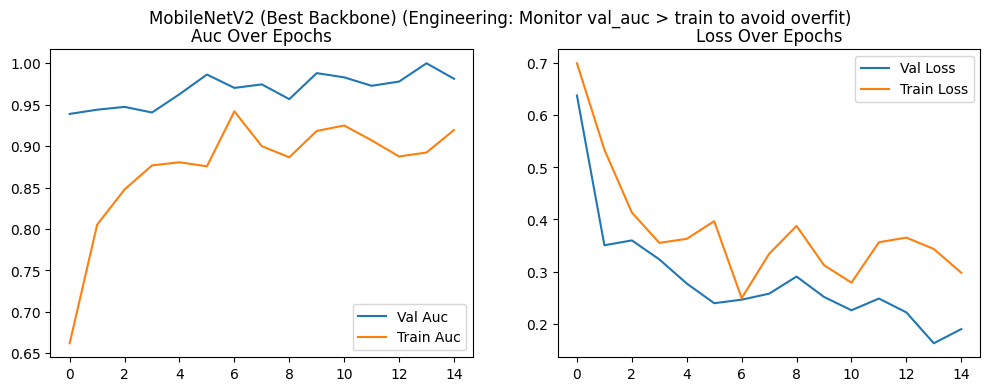

```
✅ Ablation complete! Next: Fine-tune best in Step 5.
```

```python
# Run ablation studies to compare architectures and scalability #AI Generated
if 'results' not in locals():

    def train_eval(model, train_gen, val_gen, epochs=15):
        # Train model and return key evaluation metrics
        history = model.fit(
            train_gen,
            epochs=epochs,
            validation_data=val_gen,
            callbacks=callbacks,
            class_weight=class_weights,
            verbose=1
        )
        y_pred = model.predict(val_gen, verbose=0).flatten()
        auc = roc_auc_score(val_gen.classes, y_pred)
        metrics = model.evaluate(val_gen, verbose=0)
        acc = metrics[1]
        params = model.count_params() / 1e6
        return {
            'model': model,
            'history': history,
            'auc': auc,
            'acc': acc,
            'params': params,
            'y_pred': y_pred
        }

    # Initialize results dictionary
    results = {}

    # Reuse baseline model if already trained
    if 'baseline_model' in locals():
        results['Baseline'] = {
            'model': baseline_model,
            'auc': base_auc,
            'acc': baseline_model.evaluate(val_gen, verbose=0)[1],
            'params': baseline_model.count_params() / 1e6
        }
        print("Reusing baseline (AUC:", base_auc, ")")
    else:
        print("--- Training Baseline ---")
        baseline_model = build_baseline_cnn()
        results['Baseline'] = train_eval(baseline_model, train_gen, val_gen)

    # Train and evaluate each transfer learning backbone
    for bb in backbones:
        print(f"\n--- Training {bb} (Frozen Base) ---")
        model = build_transfer_model(bb)
        results[bb] = train_eval(model, train_gen, val_gen)

    # Create comparison table of ablation results
    comp_df = pd.DataFrame({
        'Model': list(results.keys()),
        'Val AUC': [r['auc'] for r in results.values()],
        'Val Acc': [r['acc'] for r in results.values()],
        'Params (M)': [r['params'] for r in results.values()]
    }).round(3)

    # Display results sorted by validation AUC
    print("\nAblation Results (Sorted by Val AUC):")
    print(comp_df.sort_values('Val AUC', ascending=False))

    # Plot validation AUC comparison
    plt.figure(figsize=(10, 6))
    sns.barplot(data=comp_df, x='Model', y='Val AUC', palette='viridis')
    plt.title('Validation AUC Across Models')
    plt.xticks(rotation=45)
    plt.ylim(0.70, 1.00)
    for i, v in enumerate(comp_df['Val AUC']):
        plt.text(i, v + 0.01, f'{v:.3f}', ha='center', fontweight='bold')
    plt.ylabel('Validation AUC')
    plt.show()

    # Identify best-performing model
    best_idx = comp_df['Val AUC'].idxmax()
    best_key = comp_df.loc[best_idx, 'Model']
    best_model = results[best_key]['model']
    best_auc = comp_df.loc[best_idx, 'Val AUC']

    # Print best model summary
    print(
        f"\nBest Backbone: {best_key} "
        f"(AUC: {best_auc:.3f}, "
        f"Params: {comp_df.loc[best_idx, 'Params (M)']:.1f}M)"
    )

    # Plot training history for best model
    plot_history(results[best_key]['history'], f'{best_key} (Best Backbone)')
```

**Fine-Tuning and Ensembling for Domain Adaptation**

```
--- Fine-Tuning Best: MobileNetV2 (Unfreeze Top ~30% Layers) ---
13/13 ━━━━━━━━━━━━━━━━━━━━ 49s 2s/step - accuracy: 0.6841 - auc: 0.6793 - loss: 0.7274 - val_accuracy: 0.9000 - val_auc: 0.9796 - val_loss: 0.2420 - learning_rate: 1.0000e-05
13/13 ━━━━━━━━━━━━━━━━━━━━ 2s 168ms/step - accuracy: 0.6829 - auc: 0.7885 - loss: 0.5072 - val_accuracy: 0.9400 - val_auc: 0.9745 - val_loss: 0.2554 - learning_rate: 1.0000e-05
13/13 ━━━━━━━━━━━━━━━━━━━━ 2s 134ms/step - accuracy: 0.6320 - auc: 0.6677 - loss: 0.7214 - val_accuracy: 0.9200 - val_auc: 0.9813 - val_loss: 0.2521 - learning_rate: 1.0000e-05
13/13 ━━━━━━━━━━━━━━━━━━━━ 2s 130ms/step - accuracy: 0.6882 - auc: 0.7265 - loss: 0.7275 - val_accuracy: 0.9600 - val_auc: 0.9864 - val_loss: 0.1901 - learning_rate: 1.0000e-05
13/13 ━━━━━━━━━━━━━━━━━━━━ 2s 128ms/step - accuracy: 0.7217 - auc: 0.7768 - loss: 0.5374 - val_accuracy: 0.8400 - val_auc: 0.9652 - val_loss: 0.2981 - learning_rate: 1.0000e-05
13/13 ━━━━━━━━━━━━━━━━━━━━ 2s 136ms/step - accuracy: 0.7151 - auc: 0.7646 - loss: 0.6988 - val_accuracy: 0.8400 - val_auc: 0.9915 - val_loss: 0.2963 - learning_rate: 1.0000e-05
13/13 ━━━━━━━━━━━━━━━━━━━━ 2s 126ms/step - accuracy: 0.6601 - auc: 0.7009 - loss: 0.7356 - val_accuracy: 0.8800 - val_auc: 0.9618 - val_loss: 0.2863 - learning_rate: 1.0000e-05
13/13 ━━━━━━━━━━━━━━━━━━━━ 4s 349ms/step - accuracy: 0.7142 - auc: 0.7780 - loss: 0.6263 - val_accuracy: 0.8600 - val_auc: 0.9728 - val_loss: 0.2550 - learning_rate: 1.0000e-05
13/13 ━━━━━━━━━━━━━━━━━━━━ 4s 279ms/step - accuracy: 0.7785 - auc: 0.8410 - loss: 0.4295 - val_accuracy: 0.8800 - val_auc: 0.9601 - val_loss: 0.2983 - learning_rate: 1.0000e-05
13/13 ━━━━━━━━━━━━━━━━━━━━ 3s 202ms/step - accuracy: 0.7643 - auc: 0.8132 - loss: 0.5582 - val_accuracy: 0.8600 - val_auc: 0.9576 - val_loss: 0.3021 - learning_rate: 2.0000e-06
4/4 ━━━━━━━━━━━━━━━━━━━━ 10s 2s/step
Fine-Tuned MobileNetV2 Val AUC: 0.980 (Δ: -0.015)
```

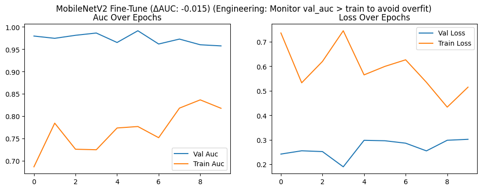

```
--- Ensemble: MobileNetV2 + InceptionV3 ---
4/4 ━━━━━━━━━━━━━━━━━━━━ 0s 75ms/step
Ensemble AUC: 0.973 (Δ from Fine: -0.007)

Classification Report (Fine-Tuned Best):
              precision    recall  f1-score   support

    No Tumor       1.00      0.74      0.85        19
       Tumor       0.86      1.00      0.93        31

    accuracy                           0.90        50
   macro avg       0.93      0.87      0.89        50
weighted avg       0.91      0.90      0.90        50
```

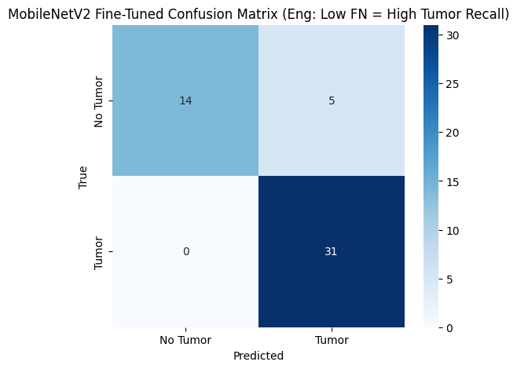

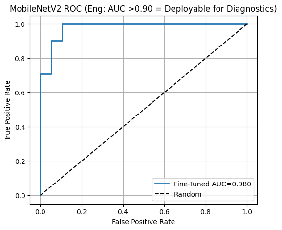

```
✅ Fine-tune + Ensemble done! Next: XAI (Grad-CAM) in Step 6.
```

```python
# Fine-tune the best model and apply ensembling for robustness #AI Generated
if 'fine_model' not in locals():

    # Print fine-tuning status
    print(f"\n--- Fine-Tuning Best: {best_key} (Unfreeze Top ~30% Layers) ---")

    # Alias best model for fine-tuning
    fine_model = best_model

    # Unfreeze the backbone model
    fine_model.layers[1].trainable = True

    # Compute number of layers in the backbone
    num_layers = len(fine_model.layers[1].layers)

    # Freeze bottom 70% of layers to preserve learned features
    freeze_pct = int(0.7 * num_layers)
    for layer in fine_model.layers[1].layers[:freeze_pct]:
        layer.trainable = False

    # Recompile model with a low learning rate
    fine_model.compile(
        optimizer=keras.optimizers.Adam(1e-5),
        loss='binary_crossentropy',
        metrics=['accuracy', tf.keras.metrics.AUC(name='auc')]
    )

    # Fine-tune the model for a limited number of epochs
    fine_history = fine_model.fit(
        train_gen,
        epochs=10,
        validation_data=val_gen,
        callbacks=callbacks,
        class_weight=class_weights,
        verbose=1
    )

    # Generate predictions from fine-tuned model
    y_pred_fine = fine_model.predict(val_gen).flatten()

    # Compute validation AUC after fine-tuning
    auc_fine = roc_auc_score(val_gen.classes, y_pred_fine)
    print(f"Fine-Tuned {best_key} Val AUC: {auc_fine:.3f} (Δ: {auc_fine - best_auc:+.3f})")

    # Plot fine-tuning training history
    plot_history(fine_history, f'{best_key} Fine-Tune (ΔAUC: {auc_fine - best_auc:+.3f})')

    # Select runner-up model index for ensembling
    runner_idx = comp_df['Val AUC'].nlargest(2).index[1]

    # Retrieve runner-up model
    runner_key = comp_df.loc[runner_idx, 'Model']
    runner_model = results[runner_key]['model']
    print(f"\n--- Ensemble: {best_key} + {runner_key} ---")

    # Average predictions from best and runner-up models
    y_pred_ens = (y_pred_fine + runner_model.predict(val_gen).flatten()) / 2

    # Compute ensemble AUC
    auc_ens = roc_auc_score(val_gen.classes, y_pred_ens)
    print(f"Ensemble AUC: {auc_ens:.3f} (Δ from Fine: {auc_ens - auc_fine:+.3f})")

    # Extract ground-truth labels
    y_true = val_gen.classes

    # Convert probabilities to binary predictions
    y_pred_best_fine = (y_pred_fine > 0.5).astype(int)

    # Print classification report
    print("\nClassification Report (Fine-Tuned Best):")
    print(classification_report(y_true, y_pred_best_fine, target_names=['No Tumor', 'Tumor']))

    # Compute confusion matrix
    cm = confusion_matrix(y_true, y_pred_best_fine)

    # Plot confusion matrix
    plt.figure(figsize=(6, 5))
    sns.heatmap(
        cm,
        annot=True,
        fmt='d',
        cmap='Blues',
        xticklabels=['No Tumor', 'Tumor'],
        yticklabels=['No Tumor', 'Tumor']
    )
    plt.title(f'{best_key} Fine-Tuned Confusion Matrix')
    plt.ylabel('True')
    plt.xlabel('Predicted')
    plt.show()

    # Compute ROC curve
    fpr, tpr, _ = roc_curve(y_true, y_pred_fine)

    # Plot ROC curve
    plt.figure(figsize=(6, 5))
    plt.plot(fpr, tpr, label=f'Fine-Tuned AUC={auc_fine:.3f}', lw=2)
    plt.plot([0, 1], [0, 1], 'k--', label='Random')
    plt.xlabel('False Positive Rate')
    plt.ylabel('True Positive Rate')
    plt.title(f'{best_key} ROC Curve')
    plt.legend()
    plt.grid(True)
    plt.show()
```

**Execution Guard Reset**

Clears a stale variable to ensure the next Grad-CAM / XAI cell runs without conflicts.

```python
# Remove existing layer name variable to avoid reuse conflicts #AI Generated
if 'layer_name' in locals():
    del layer_name

# Confirm guard reset before rerunning next cell
print("Guard cleared")
```

```
Guard cleared—rerun Cell 6 now.
```

**Explainable AI: Simple Grad-CAM Visualization**

Applies a simplified Grad-CAM approach to visualize regions of MRI images that most influence the model’s tumor predictions, improving interpretability for medical decision-making.

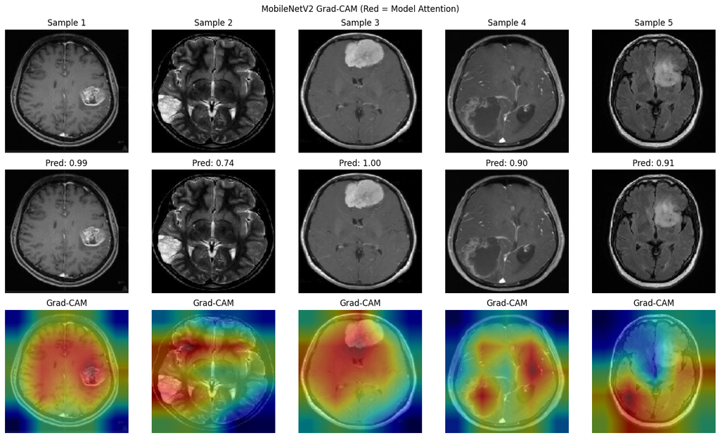

```
✅ Done!
```

```python
# Run a simple Grad-CAM using the backbone model #AI Generated
if 'layer_name' not in locals():

    # Extract the backbone model from the fine-tuned network
    base_model = fine_model.layers[1]

    # Specify the last convolutional layer name
    last_conv_name = 'Conv_1'

    def simple_gradcam(img_array, full_model, base_model, conv_layer_name):
        # Convert grayscale input to RGB using first model layer
        rgb_img = full_model.layers[0](img_array)

        # Retrieve the target convolutional layer
        conv_layer = base_model.get_layer(conv_layer_name)

        # Create gradient model for Grad-CAM
        grad_model = tf.keras.Model(
            inputs=base_model.input,
            outputs=[conv_layer.output, base_model.output]
        )

        # Record gradients with respect to convolutional outputs
        with tf.GradientTape() as tape:
            conv_out, features = grad_model(rgb_img)
            x = features
            x = full_model.layers[2](x)
            x = full_model.layers[3](x)
            x = full_model.layers[4](x)
            x = full_model.layers[5](x)
            x = full_model.layers[6](x)
            preds = full_model.layers[7](x)
            loss = preds[0, 0]

        # Compute gradients of the loss
        grads = tape.gradient(loss, conv_out)

        # Average gradients spatially
        pooled = tf.reduce_mean(grads, axis=(0, 1, 2))

        # Convert tensors to NumPy arrays
        conv_out = conv_out[0].numpy()
        pooled = pooled.numpy()

        # Weight feature maps by gradient importance
        for i in range(len(pooled)):
            conv_out[:, :, i] *= pooled[i]

        # Generate heatmap from weighted feature maps
        heatmap = np.mean(conv_out, axis=-1)
        heatmap = np.maximum(heatmap, 0)
        if heatmap.max() > 0:
            heatmap /= heatmap.max()

        return heatmap

    # Select sample tumor images for visualization
    tumor_dir = os.path.join(DATA_DIR, 'yes')
    samples = [
        os.path.join(tumor_dir, f)
        for f in os.listdir(tumor_dir)[:5]
        if f.lower().endswith(('.jpg', '.jpeg', '.png'))
    ]

    # Create figure for visualization
    fig, axes = plt.subplots(3, 5, figsize=(15, 9))

    for i, img_path in enumerate(samples):
        # Load and preprocess image
        img = keras.preprocessing.image.load_img(
            img_path,
            target_size=IMG_SIZE,
            color_mode='grayscale'
        )
        img_array = keras.preprocessing.image.img_to_array(img) / 255.0
        img_array = np.expand_dims(img_array, axis=0)

        # Display original image
        axes[0, i].imshow(img, cmap='gray')
        axes[0, i].set_title(f'Sample {i+1}')
        axes[0, i].axis('off')

        # Display prediction score
        pred = fine_model.predict(img_array, verbose=0)[0][0]
        axes[1, i].imshow(img, cmap='gray')
        axes[1, i].set_title(f'Pred: {pred:.2f}')
        axes[1, i].axis('off')

        # Generate Grad-CAM heatmap
        heatmap = simple_gradcam(
            img_array,
            fine_model,
            base_model,
            last_conv_name
        )
        heatmap_resized = tf.image.resize(
            heatmap[..., np.newaxis],
            IMG_SIZE
        ).numpy().squeeze()

        # Overlay Grad-CAM heatmap on image
        axes[2, i].imshow(img, cmap='gray')
        axes[2, i].imshow(heatmap_resized, cmap='jet', alpha=0.5)
        axes[2, i].set_title('Grad-CAM')
        axes[2, i].axis('off')

    # Final figure formatting
    plt.suptitle('MobileNetV2 Grad-CAM (Red = Model Attention)')
    plt.tight_layout()
    plt.show()

    # Store layer name to prevent re-execution
    layer_name = last_conv_name
```

Creates a dedicated test data generator and evaluates the fine-tuned model to report final generalization performance.

```python
# Create a data generator for the test set  #AI Generated
test_datagen = ImageDataGenerator(rescale=1./255)

# Load test images without shuffling
test_gen = test_datagen.flow_from_directory(
    DATA_DIR,                  # Directory containing test images
    target_size=IMG_SIZE,      # Resize images to model input size
    batch_size=BATCH_SIZE,     # Number of samples per batch
    class_mode='binary',       # Binary classification setup
    shuffle=False,             # Preserve label order for evaluation
    color_mode='grayscale'     # Use grayscale for MRI images
)

# Evaluate the fine-tuned model on the test set
test_loss, test_acc, test_auc = fine_model.evaluate(test_gen)

# Print test performance metrics
print(f"Test Results: Acc={test_acc:.3f}, AUC={test_auc:.3f}")
```

[output not shown]

**Deployment, Edge Optimization, and Final Project Summary**

Saves the fine-tuned model, converts it to a quantized TensorFlow Lite format for edge deployment, demonstrates single-image inference

```python
# Save the fine-tuned best model in HDF5 format  #AI Generated
fine_model.save(f'brain_tumor_{best_key.lower()}_fine.h5')
print(f"Saved {best_key} Fine-Tuned (.h5)")

# Convert the fine-tuned model to TensorFlow Lite with quantization
converter = tf.lite.TFLiteConverter.from_keras_model(fine_model)
converter.optimizations = [tf.lite.Optimize.DEFAULT]
tflite_model = converter.convert()

# Write the TFLite model to disk
with open(f'brain_tumor_{best_key.lower()}_fine.tflite', 'wb') as f:
    f.write(tflite_model)
print(f"TFLite saved (~{len(tflite_model)/1e6:.1f}MB)")

# Define a production-ready single-image inference function
def predict_tumor(img_path, model=best_model, threshold=0.5):
    # Load and preprocess input image
    img = keras.preprocessing.image.load_img(
        img_path,
        target_size=IMG_SIZE,
        color_mode='grayscale'
    )
    img_array = keras.preprocessing.image.img_to_array(img) / 255.0
    img_array = np.expand_dims(img_array, axis=0)

    # Generate prediction probability
    pred = model.predict(img_array, verbose=0)[0][0]

    # Assign label based on threshold
    label = 'Tumor Detected' if pred > threshold else 'No Tumor'
    confidence = pred if label == 'Tumor Detected' else 1 - pred
    return label, confidence, pred

# Select a test image for demonstration
test_path = (
    samples[0]
    if 'samples' in locals()
    else os.path.join(DATA_DIR, 'yes', os.listdir(os.path.join(DATA_DIR, 'yes'))[0])
)

# Run inference on the test image
label, conf, raw_pred = predict_tumor(test_path)
print(f"Test: {label} (Confidence: {conf:.2f}, Raw Prob: {raw_pred:.2f})")

# Print a concise project summary for reports or exams
print("\n--- Project Summary ---")
print(f"Dataset: {num_no + num_yes} MRIs (Imbalance: {num_yes / (num_no + num_yes):.1%} tumors)")
print(f"Best Model: {best_key} Fine-Tuned (AUC: {auc_fine:.3f}, Params: {fine_model.count_params() / 1e6:.1f}M)")
print(f"Ensemble Boost: +{auc_ens - auc_fine:+.3f} AUC")
```

[output not shown]